# Assignment 1

Due at 11:59pm on September 16.

Author

Ted Van Green

This assignment is to be submitted individually. Turn in this assignment as an HTML or PDF file to ELMS. Make sure to include the R Markdown or Quarto file that was used to generate it. You should include the questions in your solutions. You may use the qmd file of the assignment provided to insert your answers.

## Git and GitHub

1) Provide the link to the GitHub repo that you used to practice git from Week 1. It should have:

- Your name on the README file.
- At least one commit with your name, with a description of what you did in that commit.

Here is the link to the github repository for part one: https://github.com/danapopky/Popky_VanGreen

For the rest of the assignment, here is the repository: https://github.com/tedvangreen-umd/SURV727-assignment1

## Reading Data

Download both the Angell.dta (Stata data format) dataset and the Angell.txt dataset from this website: https://stats.idre.ucla.edu/stata/examples/ara/applied-regression-analysis-by-fox-data-files/

2) Read in the .dta version and store in an object called `angell_stata`.

```r
#reading in the dta file
library(haven)

angell_stata <- read_dta("angell (1).dta")
```

3) Read in the .txt version and store it in an object called `angell_txt`.

```r
#reading in the txt file
library(readr)
angell_txt <- read_table("angell-txt.txt", col_names = F)
```

4) What are the differences between `angell_stata` and `angell_txt`? Are there differences in the classes of the individual columns?

```r
#looking at the classes of each of the datasets.
str(angell_stata)
```

```
tibble [43 × 5] (S3: tbl_df/tbl/data.frame)
 $ city  : chr [1:43] "Rochester" "Syracuse" "Worcester" "Erie" ...
  ..- attr(*, "format.stata")= chr "%15s"
 $ morint: num [1:43] 19 17 16.4 16.2 15.8 ...
  ..- attr(*, "format.stata")= chr "%9.0g"
 $ ethhet: num [1:43] 20.6 15.6 22.1 14 17.4 ...
  ..- attr(*, "format.stata")= chr "%9.0g"
 $ geomob: num [1:43] 15 20.2 13.6 14.8 17.6 ...
  ..- attr(*, "format.stata")= chr "%9.0g"
 $ region: chr [1:43] "E" "E" "E" "E" ...
  ..- attr(*, "format.stata")= chr "%9s"
```

```r
str(angell_txt)
```

```
spc_tbl_ [43 × 6] (S3: spec_tbl_df/tbl_df/tbl/data.frame)
 $ X1: chr [1:43] "Rochester" "Syracuse" "Worcester" "Erie" ...
 $ X2: num [1:43] 19 17 16.4 16.2 15.8 15.3 15.2 14.3 14.2 14.1 ...
 $ X3: num [1:43] 20.6 15.6 22.1 14 17.4 27.9 22.3 23.7 10.6 12.7 ...
 $ X4: num [1:43] 15 20.2 13.6 14.8 17.6 17.5 14.7 23.8 19.4 31.9 ...
 $ X5: chr [1:43] "E" "E" "E" "E" ...
 $ X6: logi [1:43] NA NA NA NA NA NA ...
 - attr(*, "problems")= tibble [14 × 5] (S3: tbl_df/tbl/data.frame)
  ..$ row     : int [1:14] 5 8 10 11 13 14 16 17 20 21 ...
  ..$ col     : chr [1:14] NA NA NA NA ...
  ..$ expected: chr [1:14] "6 columns" "6 columns" "6 columns" "6 columns" ...
  ..$ actual  : chr [1:14] "5 columns" "5 columns" "5 columns" "5 columns" ...
  ..$ file    : chr [1:14] "'angell-txt.txt'" "'angell-txt.txt'" "'angell-txt.txt'" "'angell-txt.txt'" ...
 - attr(*, "spec")=
  .. cols(
  ..   X1 = col_character(),
  ..   X2 = col_double(),
  ..   X3 = col_double(),
  ..   X4 = col_double(),
  ..   X5 = col_character(),
  ..   X6 = col_logical()
  .. )
```

There is an extra column in the angell_txt version. There don’t appear to be differences between the classes of the columns in each one. There are no column names for the txt file.

5) Make any updates necessary so that `angell_txt` is the same as `angell_stata`.

```r
#dropping the last column from the txt version of the data
angell_txt <- angell_txt[,c(1:5)]

#adding column names
colnames(angell_txt) <- colnames(angell_stata)
colnames(angell_stata)
```

```
[1] "city"   "morint" "ethhet" "geomob" "region"
```

```r
colnames(angell_txt)
```

```
[1] "city"   "morint" "ethhet" "geomob" "region"
```

I added column names to the txt file, as well as dropped the column of NAs from that file as well.

6) Describe the Ethnic Heterogeneity variable. Use descriptive statistics such as mean, median, standard deviation, etc. How does it differ by region?

```r
#using summary and sd, then looking by region
summary(angell_stata$ethhet)
```

```
   Min. 1st Qu.  Median    Mean 3rd Qu.    Max.
  10.60   16.90   23.70   31.37   39.00   84.50
```

```r
sd(angell_stata$ethhet)
```

```
[1] 20.41149
```

```r
library(tidyverse)
#ethhet by region
angell_stata %>%
  group_by(region) %>%
  summarize(min = min(ethhet),
            max = max(ethhet),
            mean = mean(ethhet),
            median = median(ethhet),
            sd = sd(ethhet))
```

```
# A tibble: 4 × 6
  region   min   max  mean median    sd
  <chr>  <dbl> <dbl> <dbl>  <dbl> <dbl>
1 E       10.6  45.8  23.5   22.1 10.8
2 MW      10.7  39.7  21.7   19.2  9.08
3 S       20.7  84.5  52.5   53.8 21.4
4 W       12.3  23.9  16.5   16.1  4.16
```

The mean is 31.37, the median is 23.7, the standard deviation is 20.41.

By region, the south has a higher mean and median than other regions, while the west has a slightly lower value on both. The south has a much higher standard deviation.

## Describing Data

R comes also with many built-in datasets. The “MASS” package, for example, comes with the “Boston” dataset.

7) Install the “MASS” package, load the package. Then, load the Boston dataset.

```r
#reading in the data
#install.packages("MASS")
library(MASS)
data("Boston")
```

8) What is the type of the Boston object?

```r
#getting type of object
typeof(Boston)
```

```
[1] "list"
```

The type of the Boston object is a list

9) What is the class of the Boston object?

```r
#what class is the object
class(Boston)
```

```
[1] "data.frame"
```

The class is a data frame

10) How many of the suburbs in the Boston data set bound the Charles river?

```r
#looking at the chas variable
table(Boston$chas)
```

```
  0   1
471  35
```

There are 35 suburbs that bound the river.

11) Do any of the suburbs of Boston appear to have particularly high crime rates? Tax rates? Pupil-teacher ratios? Comment on the range of each variable.

```r
#summary of the crim variable and a boxplot
summary(Boston$crim)
```

```
    Min.  1st Qu.   Median     Mean  3rd Qu.     Max.
 0.00632  0.08204  0.25651  3.61352  3.67708 88.97620
```

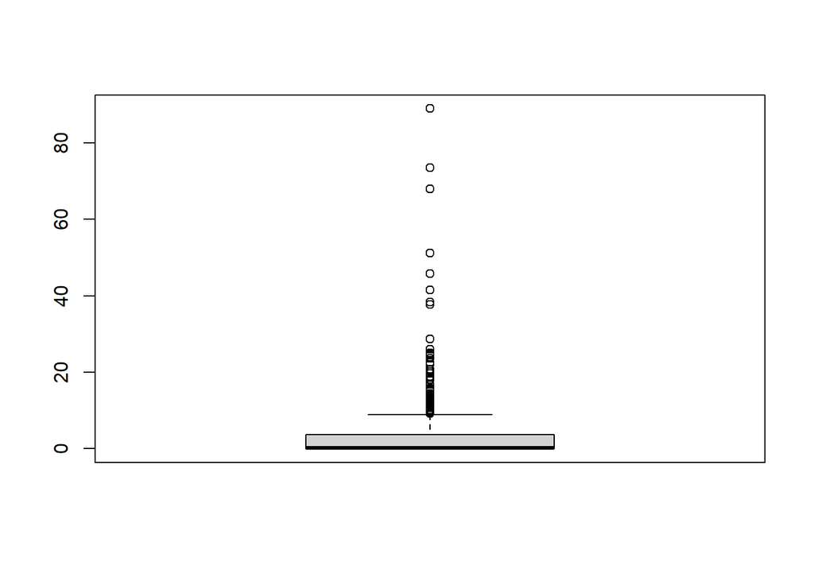

```r
boxplot(Boston$crim)
```

```r
#summary of the tax variable and a boxplot
summary(Boston$tax)
```

```
   Min. 1st Qu.  Median    Mean 3rd Qu.    Max.
  187.0   279.0   330.0   408.2   666.0   711.0
```

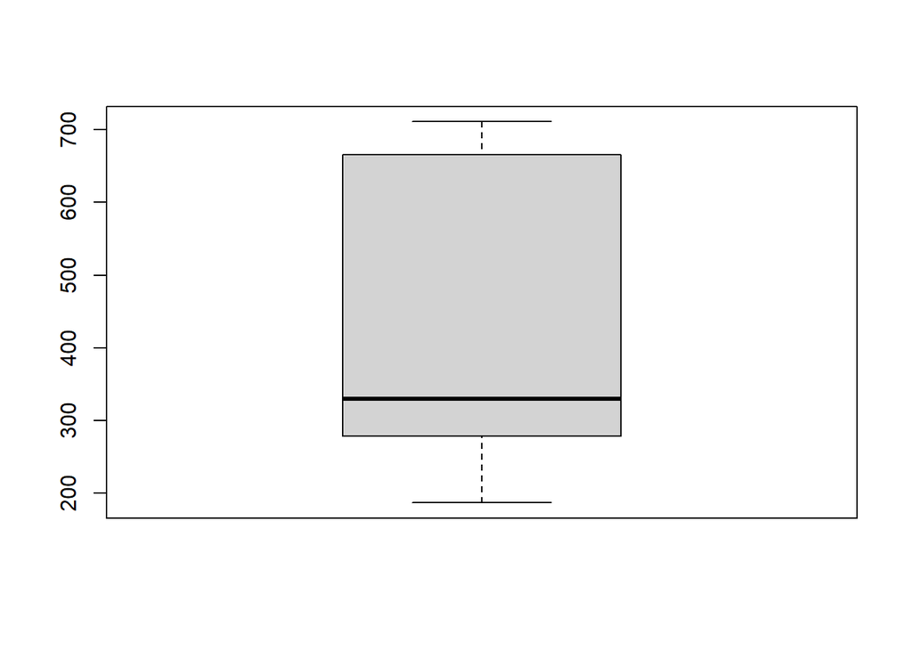

```r
boxplot(Boston$tax)
```

There are a couple that have somewhat higher tax rates than others, although unlike crime rates there are not extreme outliers. the mean is higher than the median so there are some higher tax suburbs raising the mean up, with a IQR of 279-666.

```r
#summary of the ptratio variable and a boxplot
summary(Boston$ptratio)
```

```
   Min. 1st Qu.  Median    Mean 3rd Qu.    Max.
  12.60   17.40   19.05   18.46   20.20   22.00
```

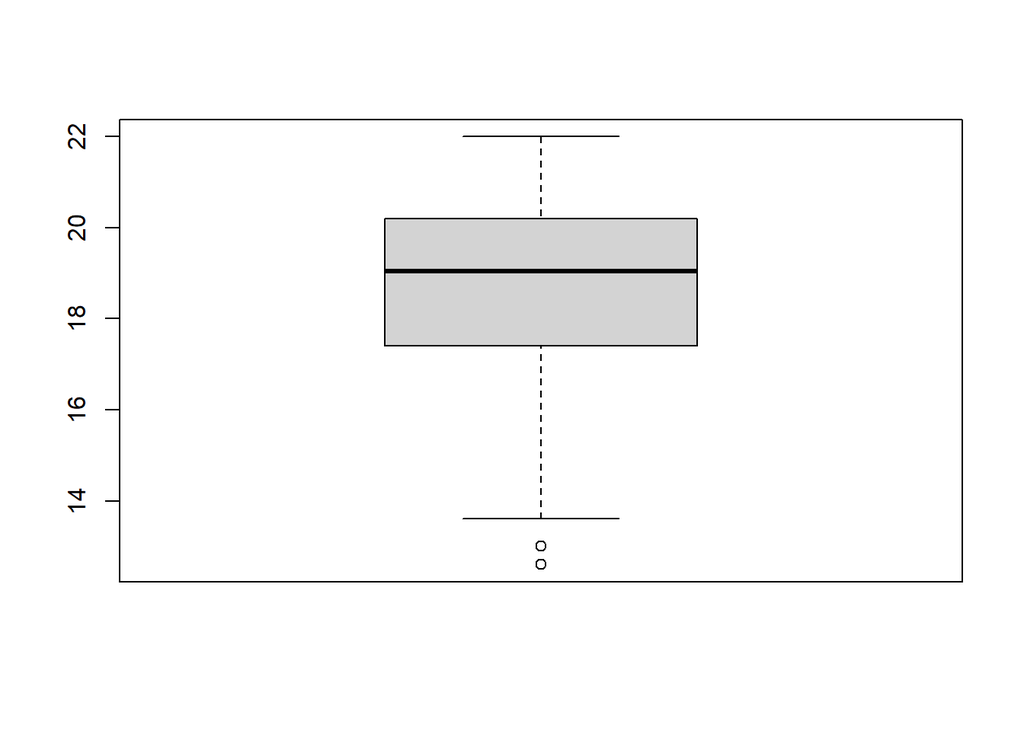

```r
boxplot(Boston$ptratio)
```

There are a couple of districts with fairly low parent teacher ratios, but this spread is less extreme than the crime rates one as well. Most ratios seem to be between 17-20.

12) Describe the distribution of pupil-teacher ratio among the towns in this data set that have a per capita crime rate larger than 1. How does it differ from towns that have a per capita crime rate smaller than 1?

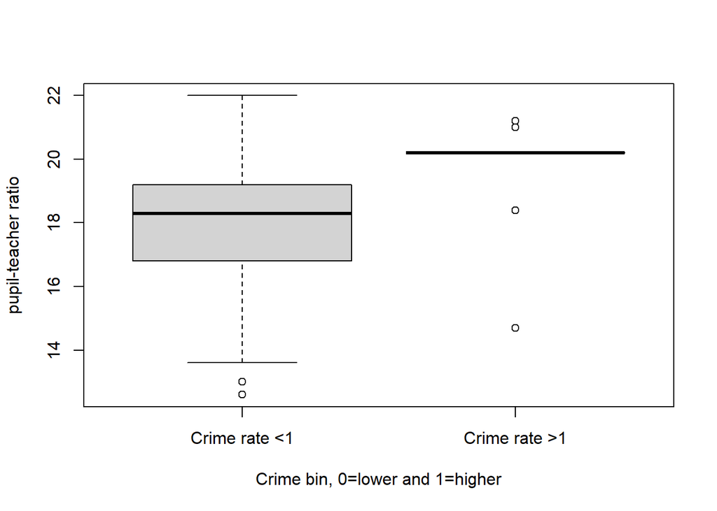

```r
#recoding the crime variable into a binary
Boston$crime_bin <- ifelse(Boston$crim>1, "Crime rate >1","Crime rate <1")

#looking at the ptratio variable by the crime variable
boxplot(Boston$ptratio~Boston$crime_bin, xlab = "Crime bin, 0=lower and 1=higher",
        ylab = "pupil-teacher ratio")
```

```r
tapply(Boston$ptratio, Boston$crime_bin, summary)
```

```
$`Crime rate <1`
   Min. 1st Qu.  Median    Mean 3rd Qu.    Max.
  12.60   16.80   18.30   18.02   19.20   22.00

$`Crime rate >1`
   Min. 1st Qu.  Median    Mean 3rd Qu.    Max.
  14.70   20.20   20.20   19.29   20.20   21.20
```

```r
Boston %>%
  group_by(crime_bin) %>%
  summarize(min=min(ptratio),
            max = max(ptratio),
            mean = mean(ptratio),
            median = median(ptratio),
            IQR = IQR(ptratio))
```

```
# A tibble: 2 × 6
  crime_bin       min   max  mean median   IQR
  <chr>         <dbl> <dbl> <dbl>  <dbl> <dbl>
1 Crime rate <1  12.6  22    18.0   18.3   2.4
2 Crime rate >1  14.7  21.2  19.3   20.2   0
```

There is less of a spread in those districts that have a crime rate greater than 1, with the 1st quartile and the 3rd quartile having the same value. For those with a lower crime rate, there is more of a spread between the first and third quartile (16.8-19.2)

## Writing Functions

13) Write a function that calculates 95% confidence intervals for a point estimate. The function should be called `my_CI`. When called with `my_CI(2, 0.2)`, the function should print out “The 95% CI upper bound of point estimate 2 with standard error 0.2 is 2.392. The lower bound is 1.608.”

*Note: The function should take a point estimate and its standard error as arguments. You may use the formula for 95% CI: point estimate +/- 1.96*standard error.*

*Hint: Pasting text in R can be done with:* `paste()` *and* `paste0()`

```r
my_CI <- function(mean, se){
  lower <- round(mean - (1.96*se),3)
  upper <- round(mean + (1.96*se),3)

  function_message <- paste0("The 95% CI upper bound of point estimate ",
                            mean, " with standard error ", se,
                            " is ", upper, ". The lower bound is ",
                            lower, ".")
  print(function_message)
}

my_CI(2,0.2)
```

```
[1] "The 95% CI upper bound of point estimate 2 with standard error 0.2 is 2.392. The lower bound is 1.608."
```

This is the output of the function

14) Create a new function called `my_CI2` that does that same thing as the `my_CI` function but outputs a vector of length 2 with the lower and upper bound of the confidence interval instead of printing out the text. Use this to find the 95% confidence interval for a point estimate of 0 and standard error 0.4.

```r
my_CI2 <- function(mean, se){
  lower <- round(mean - (1.96*se),3)
  upper <- round(mean + (1.96*se),3)

  return(c(lower,upper))
}

my_CI2(0,0.4)
```

```
[1] -0.784  0.784
```

The 95% confidence interval is -0.784-0.784.

15) Update the `my_CI2` function to take any confidence level instead of only 95%. Call the new function `my_CI3`. You should add an argument to your function for confidence level.

*Hint: Use the* `qnorm` *function to find the appropriate z-value. For example, for a 95% confidence interval, using* `qnorm(0.975)` *gives approximately 1.96.*

```r
#note: can't just have it be straight confidence level per the example above
my_CI3 <- function(mean, se, ci_level){
  z_score <- qnorm(1-(1-ci_level)/2)

  lower <- round(mean - (z_score*se),3)
  upper <- round(mean + (z_score*se),3)

  return(c(lower,upper))
}

my_CI3(0,0.4,0.95)
```

```
[1] -0.784  0.784
```

16) Without hardcoding any numbers in the code, find a 99% confidence interval for Ethnic Heterogeneity in the Angell dataset. Find the standard error by dividing the standard deviation by the square root of the sample size.

```r
my_CI4 <- function(col_name, ci_level){

  z <- qnorm(1-(1-ci_level)/2)
  se <- sd(col_name)/sqrt(length(col_name))

  lower <- round(mean(col_name) - (z*se),3)
  upper <- round(mean(col_name) + (z*se),3)
  return(c(lower,upper))

}

my_CI4(angell_stata$ethhet, .99)
```

```
[1] 23.354 39.390
```

The 99% confidence interval for the ethnic heterogeneity is 23.354-39.39.

17) Write a function that you can `apply` to the Angell dataset to get 95% confidence intervals. The function should take one argument: a vector. Use if-else statements to output NA and avoid error messages if the column in the data frame is not numeric or logical.

```r
my_CI5 <- function(dataset){
  output <- NULL
  #subsetting so this runs on each column
  for(i in colnames(dataset)) {
  col_name <- dataset[[i]]

  #
  if(is.numeric(col_name) | is.logical(col_name)){

  se <- sd(col_name)/sqrt(length(col_name))

  lower <- round(mean(col_name) - (1.96*se),3)
  upper <- round(mean(col_name) + (1.96*se),3)

  output <- rbind(output, c(i, lower, upper))
  }
  else {
    output <- rbind(output, c(i, NA, NA))}
  }
  colnames(output) <- c("var", "lower bound", "upper bound")
  return(output)
}

my_CI5(angell_stata)
```

```
     var      lower bound upper bound
[1,] "city"   NA          NA
[2,] "morint" "10.132"    "12.268"
[3,] "ethhet" "25.271"    "37.473"
[4,] "geomob" "24.672"    "30.524"
[5,] "region" NA          NA
```

Here is that function applied to the Angel dataset.